# Worksheet 5 - Scientific Visualisation MVE080/MMG640

## Storytelling with data

Name: *Houshi He*

1. It describes the tasks.
2. It (sometimes) provides coding templates that you can use as a basis for your own code.
3. It is a template also for the report that you upload in Canvas.

The tasks are of various types: some are to read some text and then comment on it (no coding), and some are about creating visualisations using plotnine. Once you have done finished all the tasks, export this document as an HTML file and upload it in Canvas. You are encouraged to discuss problems and solutions with your fellow students, but each student must solve all tasks by themselves and hand-in their own report. Notice that Jupyter notebooks use [Markdown](https://docs.github.com/en/github/writing-on-github/getting-started-with-writing-and-formatting-on-github/basic-writing-and-formatting-syntax#links) for writing text cells. Make sure you understand the basics.

The below loads the packages required for this homework.

```python
import numpy as np
import pandas as pd
import geopandas as gpd
from plotnine import *
# Currently in a plotine dependancy they have deprication warning, so
# we mute warnings to have a better experience
import warnings
warnings.filterwarnings("ignore")

# A nice color palette for categorical data
cbPalette = ["#E69F00", "#56B4E9", "#009E73",
             "#F0E442", "#0072B2", "#D55E00",
             "#CC79A7", "#999999"]

# Always a bit risky, but I think the chance for name space convolution is small
import numpy as np
import scipy as sp
import pandas as pd
import geopandas as gpd
import matplotlib.pyplot as plt
import os
from plotnine import *
import warnings
warnings.filterwarnings("ignore")
# For handling dates
from mizani.breaks import date_breaks
from mizani.formatters import date_format

# A nice color palette for categorical data
cbPalette = ["#E69F00", "#56B4E9", "#009E73",
             "#0072B2", "#D55E00",
             "#CC79A7", "#F0E442", "#999999"]

# Proportions when saving figures
BASE_HEIGHT = 5
BASE_WIDTH = 7.0

# Directory for saving figures
dir_save = "./Figs/"
if not os.path.isdir(dir_save):
    os.mkdir(dir_save)
```

## Storytelling with data

For this part reading chapter 20 in [Fundamentals of Data Visualizations](https://clauswilke.com/dataviz/) can help. An important part for making people interact with your visual is that it looks good, therefore, for this part I will also judge the aesthetics of the visual, as well as how efficiently it conveys its main message.

### Question 1.1

To make a visual accessible it is important to think like a designer - and a key feature here is to cleverly use highlighting and text annotations. An example of a well-designed visual is the Goal-attainment visual shown in the lecture, to practice annotations recreate it. The dataset is on Canvas.

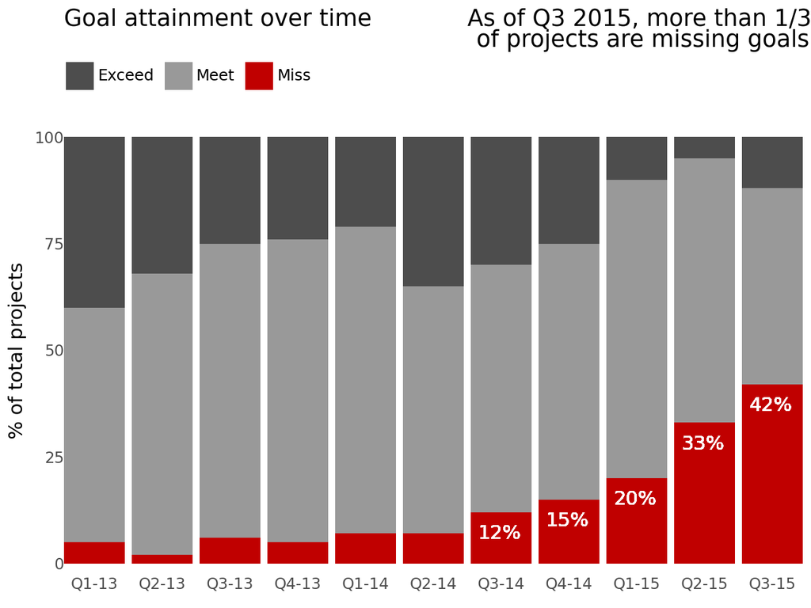

```python
# Insert code here
data = pd.read_csv("Goal_data.csv")

categories_order = [
    "Q1-13", "Q2-13", "Q3-13", "Q4-13",
    "Q1-14", "Q2-14", "Q3-14", "Q4-14",
    "Q1-15", "Q2-15", "Q3-15"
]
data['categories'] = pd.Categorical(data['categories'], categories=categories_order, ordered=True)

data['proportion'] = data.groupby('categories')['value'].transform(lambda x: (x / x.sum()) * 100)
data['proportion'] = data['proportion'].round(0)

color_mapping = {
    "Miss": "#C00000",
    "Meet": "#999999",
    "Exceed": "#4D4D4D"
}

miss_data = data[data['what'] == 'Miss']

# draw the plot
stacked_chart = (
    ggplot(data, aes(x='categories', y='proportion', fill='what')) +
    geom_bar(stat='identity', position='stack') +
    geom_text(x=6.656, y=7, label="12%", ha="left", color="#FFFFFF") +
    geom_text(x=7.656, y=10, label="15%", ha="left", color="#FFFFFF") +
    geom_text(x=8.656, y=15, label="20%", ha="left", color="#FFFFFF") +
    geom_text(x=9.656, y=28, label="33%", ha="left", color="#FFFFFF") +
    geom_text(x=10.656, y=37, label="42%", ha="left", color="#FFFFFF") +
    scale_fill_manual(values=color_mapping) +
    labs(
        title="Goal attainment over time             As of Q3 2015, more than 1/3\n                                                        of projects are missing goals",
        x="",
        y="% of total projects"
    ) +
    theme_minimal() +
    theme(
        axis_text_x=element_text(
            rotation=0,
            hjust=0.5,
            vjust=0.5
        ),
        axis_line=element_blank(),
        axis_ticks=element_blank(),
        panel_border=element_blank(),
        panel_grid=element_blank(),
        plot_title=element_text(hjust=0),
        legend_position="top",
        legend_box="horizontal",
        legend_title=element_blank(),
        legend_justification="left"
    ) +
    scale_x_discrete(
        expand=(0, 0)
    )
)

stacked_chart
# Remember to print the visual
```

Briefly comment on why red is a good choice of colour in this visual.

*I think the "Miss" part represents the items that did not reach the target. Using red can effectively convey this negative message.*

### Question 1.2

During the lecture, I gave the Spanish unemployment data a long needed makeover - specifically I made it accessible for a wider audience. Choose any visual from the slides in lecture 1-6, decide upon a point you want to make, and use the lessons from the Story telling lecture to make that point accessible.

Provide motivation to how the changes to the visual has made it more accessible.

[figure not shown]

```python
data_sweden = pd.read_csv("Sweden_pop.csv")
data_france = pd.read_csv("France_pop.csv")

data_sweden["Population"] = data_sweden["Population"] / 1e6
data_france["Population"] = data_france["Population"] / 1e6

data_tot = pd.concat([data_sweden, data_france])

# Highlight the specific points in deep blue
highlight_points = pd.DataFrame({
    'Year': [1950, 2019, 1950, 2019],
    'Population': [41.8, 65.1, 7.01, 10],
    'country': ['Sweden', 'France', 'Sweden', 'France']
})

p2 = (ggplot(data_tot, aes("Year", "Population", color="country"))
    + geom_line(size=1.0)
    + geom_point(aes(x='Year', y='Population'), data=highlight_points, color='darkblue', size=3)
    + geom_text(x=1975, y=44, label="From 1950 to 2019, \nFrance's total \npopulation grew from \n 41.8 million to 5.1 \nmillion, an increase of \napproximately 55%.", ha="left", color="#525252")
    + geom_text(x=1950, y=14, label="From 1950 to 2019, Sweden's \npopulation grew more slowly, \nfrom about 7.01 million to about\n10 million.", ha="left", color="#525252")
    + labs(y="Population [Millions]", title="Population 1900 to 2020: Sweden vs France")
    + scale_color_manual(values=cbPalette, name="Country")
    + theme_bw())

p2
```

*I highlighted key data points and added custom text annotations to make the images more visually appealing.*

### Question 1.3

On Canvas I have uploaded a made-up pie chart example from a summer pilot program, where student prior and after the program were asked how excited they were about doing science. The program was a success, but, a pie-chart is not a good way to visualize the data. Using lessons from the lecture, improve the visual, such that a wide audience can identify that the program was a success.

In the new visual make use of proper highlighting, annotations, a good title, and choose a good form of visualisation. The new visual should include all the data used in the pie chart.

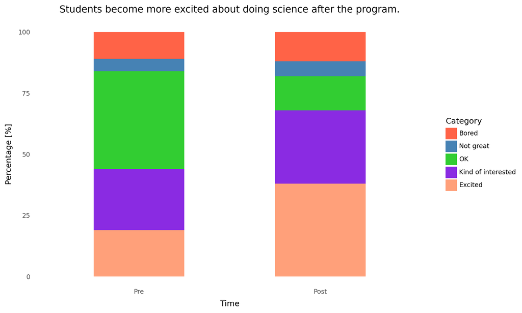

```python
# Insert code here
# Create data
data = pd.DataFrame({
    'Item': ['Pre']*5 + ['Post']*5,
    'category': ['Bored', 'Not great', 'OK', 'Kind of interested', 'Excited']*2,
    'proportion': [11, 5, 40, 25, 19, 12, 6, 14, 30, 38]
})

# Set the 'Item' column as a categorical variable with a order
data['Item'] = pd.Categorical(data['Item'], categories=['Pre', 'Post'], ordered=True)
data['category'] = pd.Categorical(data['category'], categories=['Bored', 'Not great', 'OK', 'Kind of interested', 'Excited'], ordered=True)

# Create the plot with updated colormap
plot = (
    ggplot(data, aes(x='Item', y='proportion', fill='category'))
    + geom_bar(stat='identity', position='stack', width=0.5)
    + scale_fill_manual(values=['#FF6347', '#4682B4', '#32CD32', '#8A2BE2', '#FFA07A'])
    + labs(x='Time', y='Percentage [%]', fill='Category', title='Students become more excited about doing science after the program.')
    + theme_minimal()
    + theme(
        axis_text_x=element_text(rotation=0, ha='center'),
        figure_size=(10, 6),
        panel_grid=element_blank()
    )
)

plot
# Remember to print the visual
```

### Question 1.4

Clutter is something we want to remove. On Canvas I have uploaded a visual on performance index for *Our Business* compared to other companies. Improve this visual such that it becomes easy to see how *Our Business* compares against the other companies for each category.

Provide a brief motivation to why your new visual is accessible.

*1. By setting "Our Business" to dark red and other companies to dark gray, "Our Business" is more visually prominent and easy to quickly identify and compare.*

*2. I set the point of "Our Business" to be larger and the points of other companies to be smaller. This size difference further strengthens the importance of "Our Business" in each category and improves the visualization of the data.*

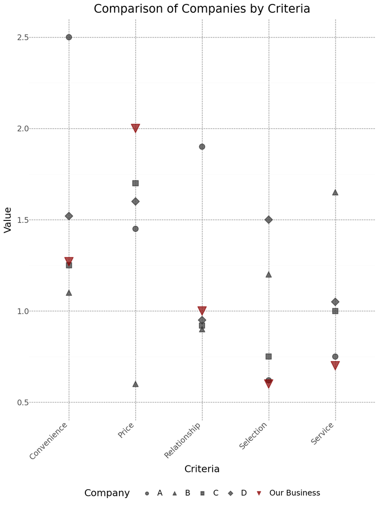

```python
# Insert code here
df = pd.read_csv('Performance_index.csv')

# draw the plot
plot = (ggplot(df, aes(x='criteria', y='value', color='company', shape='company', size='company'))
        + geom_point(alpha=0.7)
        + scale_color_manual(values={"Our Business": "#8B0000",
                                     "A": "#333333",
                                     "B": "#333333",
                                     "C": "#333333",
                                     "D": "#333333"})
        + scale_size_manual(values={"Our Business": 5,
                                    "A": 3,
                                    "B": 3,
                                    "C": 3,
                                    "D": 3})
        + lims(y=(0.5, 2.5))
        + labs(title='Comparison of Companies by Criteria', x='Criteria', y='Value', color='Company', shape='Company')
        + theme_minimal()
        + theme(axis_text_x=element_text(rotation=45, ha='right'),
                legend_position='bottom',
                figure_size=(6, 8),
                panel_grid_major=element_line(size=0.5, linetype='dashed', color='gray'))
        + guides(size=False)
)

plot
# Remember to print the visual
```

## Tables

For this part reading chapter 22 in [Fundamentals of Data Visualizations](https://clauswilke.com/dataviz/) can help.

### Question 2

A well-designed table may be a good tool to report exact amount of every value of your data. Following the lecture slides and the course book, redesign the table below to make it readable and easy to understand.

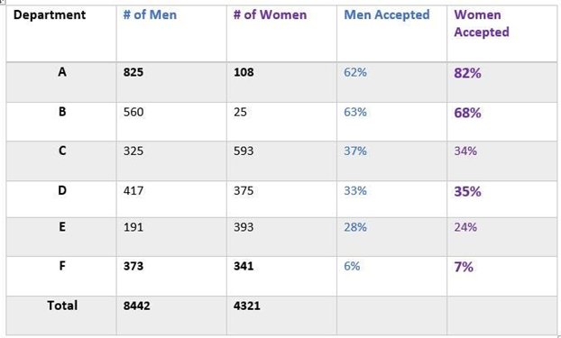

Taking a look at the table source (https://medium.com/@dexter.shawn/how-uc-berkeley-almost-got-sued-because-of-lying-data-aaa5d641f571) may help you in your decisions upon completing this task.

You may use any software (except for ChatGTP and other AI tools). Desribe what you changed and why.

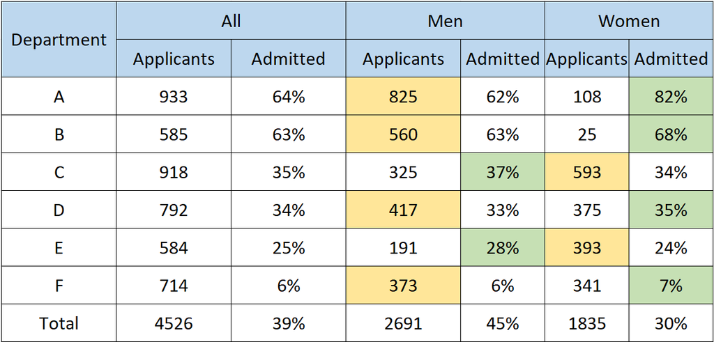

```python
from IPython.display import Image

# Display the image
Image(filename='./Simpson.png', width=1280, height=960)
```

*I use Excel to draw. I set "All" "Men" and "Women" as primary headers, with "Applicants" and "Admitted" as secondary headers beneath each category. This structure allows for a clear comparison of the number of applicants and admissions between men and women. Additionally, I highlighted the data for the gender with more applicants and the higher admission rate for each department.*

*In this way we can see the reason of Simpson's paradox, where the discrepancy in total admissions arises from the higher number of applicants in one gender, causing that gender seems to have a higher admission rate when aggregated.*